# Table of Contents

What are bixis most used routes?

Using the open data from Bixi with each rental and the list of stations

# Getting most used routes

Defining the most used paths by bixi users

```python
import pandas as pd
import folium
from math import radians, cos, sin, asin, sqrt
import requests

import matplotlib.pyplot as plt
import seaborn as sns

from credentials import *#module with key for API
```

```python
df = pd.read_csv('data/OD_2020.csv')
```

## Exploration of dataset

```python
df.head()
```

|  | start_date | start_station_code | end_date | end_station_code | duration_sec | is_member |
| --- | --- | --- | --- | --- | --- | --- |
| 0 | 2020-04-15 06:00:04 | 6212 | 2020-04-15 06:20:54 | 6250 | 1250 | 1 |
| 1 | 2020-04-15 06:05:41 | 6369 | 2020-04-15 06:32:47 | 6072 | 1626 | 1 |
| 2 | 2020-04-15 06:07:27 | 6207 | 2020-04-15 06:19:32 | 7038 | 724 | 1 |
| 3 | 2020-04-15 06:09:16 | 6202 | 2020-04-15 06:18:49 | 6212 | 572 | 1 |
| 4 | 2020-04-15 06:09:38 | 6159 | 2020-04-15 06:24:23 | 7067 | 885 | 1 |

```python
df.dtypes
```

```
start_date            object
start_station_code     int64
end_date              object
end_station_code       int64
duration_sec           int64
is_member              int64
dtype: object
```

```python
df.shape
```

[output not shown]

```python
df.describe()
```

|  | start_station_code | end_station_code | duration_sec | is_member |
| --- | --- | --- | --- | --- |
| count | 3.264741e+06 | 3.264741e+06 | 3.264741e+06 | 3.264741e+06 |
| mean | 6.399046e+03 | 6.399199e+03 | 9.363313e+02 | 7.966846e-01 |
| std | 4.269501e+02 | 4.399925e+02 | 7.234184e+02 | 4.024652e-01 |
| min | 4.000000e+03 | 4.000000e+03 | 6.100000e+01 | 0.000000e+00 |
| 25% | 6.142000e+03 | 6.134000e+03 | 4.210000e+02 | 1.000000e+00 |
| 50% | 6.237000e+03 | 6.240000e+03 | 7.530000e+02 | 1.000000e+00 |
| 75% | 6.708000e+03 | 6.712000e+03 | 1.264000e+03 | 1.000000e+00 |
| max | 1.000200e+04 | 1.000200e+04 | 7.199000e+03 | 1.000000e+00 |

## creating the routes column

```python
df['route'] = df[['start_station_code', 'end_station_code']].astype(str).agg('-'.join, axis=1)
```

```python
df.head()
```

|  | start_date | start_station_code | end_date | end_station_code | duration_sec | is_member | route |
| --- | --- | --- | --- | --- | --- | --- | --- |
| 0 | 2020-04-15 06:00:04 | 6212 | 2020-04-15 06:20:54 | 6250 | 1250 | 1 | 6212-6250 |
| 1 | 2020-04-15 06:05:41 | 6369 | 2020-04-15 06:32:47 | 6072 | 1626 | 1 | 6369-6072 |
| 2 | 2020-04-15 06:07:27 | 6207 | 2020-04-15 06:19:32 | 7038 | 724 | 1 | 6207-7038 |
| 3 | 2020-04-15 06:09:16 | 6202 | 2020-04-15 06:18:49 | 6212 | 572 | 1 | 6202-6212 |
| 4 | 2020-04-15 06:09:38 | 6159 | 2020-04-15 06:24:23 | 7067 | 885 | 1 | 6159-7067 |

```python
top_df = df.groupby('route').agg({'is_member':'count','duration_sec':'mean'})
```

```python
top_df.sort_values(by='is_member',ascending=False).head(20)
```

| route | is_member | duration_sec |
| --- | --- | --- |
| 6501-6501 | 2651 | 1842.659374 |
| 6026-6026 | 2505 | 1854.134531 |
| 6036-6036 | 2239 | 2103.002680 |
| 7125-7125 | 1804 | 1707.531596 |
| 6023-6023 | 1627 | 1924.244622 |
| 7007-7007 | 1271 | 1524.715972 |
| 7105-7105 | 1193 | 1961.806370 |
| 7103-7103 | 1168 | 2177.036815 |
| 6009-6009 | 1132 | 1061.644876 |
| 6036-6026 | 994 | 1622.658954 |
| 6232-6232 | 978 | 1117.543967 |
| 6501-6109 | 965 | 1202.513990 |
| 6184-6184 | 950 | 1195.248421 |
| 6406-6036 | 948 | 1371.289030 |
| 6724-6724 | 941 | 1783.087141 |
| 6036-6406 | 926 | 1410.187905 |
| 7119-7119 | 915 | 1937.499454 |
| 6109-6501 | 884 | 1147.692308 |
| 6081-6081 | 863 | 1079.008111 |
| 6216-6216 | 862 | 1991.812065 |

```python
top_df = top_df.sort_values(by='is_member',ascending=False)
```

```python
top_df.head(100)
```

[output not shown]

Saving stop of the dataframes

```python
df.to_pickle('df.pkl')
```

## Adding the column to detect single station trips

> So to my surprise, many users rent thir bixi from and to the same station. My hypothesis is for sightseeing, as first station coming up is the one on Jean Drapeau Island.

For this reason, deciding to separate the trips starting and ending at the same station

```python
def singleTrip(trip):
    stations = trip.split('-')
    if stations[0] == stations[1]:
        return 1
    else:
        return 0
```

```python
top_df['round_trip'] = top_df.index.map(singleTrip)
```

```python
top_df.columns = ['count','duration_sec','round_trip']
```

```python
top_df.head()
```

[output not shown]

```python
top_df = top_df.sort_values(by='count',ascending=False)
```

```python
top_df.to_pickle('top_df.pkl')
```

## Selecting non round trips

```python
top_df[top_df['round_trip']==0]
```

| route | count | duration_sec | round_trip |
| --- | --- | --- | --- |
| 6036-6026 | 994 | 1622.658954 | 0 |
| 6501-6109 | 965 | 1202.513990 | 0 |
| 6406-6036 | 948 | 1371.289030 | 0 |
| 6036-6406 | 926 | 1410.187905 | 0 |
| 6109-6501 | 884 | 1147.692308 | 0 |
| ... | ... | ... | ... |
| 6383-4001 | 1 | 2056.000000 | 0 |
| 6214-6082 | 1 | 1173.000000 | 0 |
| 6114-6254 | 1 | 1677.000000 | 0 |
| 6381-8011 | 1 | 4834.000000 | 0 |
| 6108-7126 | 1 | 3869.000000 | 0 |

219616 rows × 3 columns

```python
top10_trips = top_df[top_df['round_trip']==0].head(10)
```

```python
top10_trips
```

| route | count | duration_sec | round_trip |
| --- | --- | --- | --- |
| 6036-6026 | 994 | 1622.658954 | 0 |
| 6501-6109 | 965 | 1202.513990 | 0 |
| 6406-6036 | 948 | 1371.289030 | 0 |
| 6036-6406 | 926 | 1410.187905 | 0 |
| 6109-6501 | 884 | 1147.692308 | 0 |
| 7103-7105 | 854 | 1261.225995 | 0 |
| 6052-6406 | 848 | 1237.279481 | 0 |
| 6136-6165 | 841 | 268.017836 | 0 |
| 6052-6026 | 812 | 1063.266010 | 0 |
| 6387-6391 | 789 | 259.097592 | 0 |

# Getting the geographic data

```python
df_stations = pd.read_csv('data/stations.csv')
```

```python
df_stations.head()
```

|  | code | name | latitude | longitude |
| --- | --- | --- | --- | --- |
| 0 | 6001 | Métro Champ-de-Mars (Viger / Sanguinet) | 45.510163 | -73.556637 |
| 1 | 6002 | Ste-Catherine / Dezery | 45.539385 | -73.541000 |
| 2 | 6003 | Clark / Ontario | 45.510824 | -73.567172 |
| 3 | 6004 | du Champ-de-Mars / Gosford | 45.509655 | -73.554009 |
| 4 | 6005 | Metcalfe / du Square-Dorchester | 45.500208 | -73.571138 |

Testing grabbing info from one station

```python
df_stations[df_stations['code']==6391]
```

|  | code | name | latitude | longitude |
| --- | --- | --- | --- | --- |
| 304 | 6391 | Aylwin / Ontario | 45.544303 | -73.545473 |

## Getting coordinates of stations

```python
def getCoordinates(trip):
    stations = trip.split('-')
    coord_from = df_stations[df_stations['code']==int(stations[0])][['latitude','longitude']]#The departing station
    coord_to =df_stations[df_stations['code']==int(stations[1])][['latitude','longitude']]#The departing station
    coord = pd.concat([coord_from.reset_index(),coord_to.reset_index()],axis=1)
    coord = coord.drop('index',axis=1)
    return coord.iloc[0]
```

A test on a station to see if function works

```python
print(getCoordinates('6387-6391'))
```

```
latitude     45.546907
longitude   -73.551557
latitude     45.544303
longitude   -73.545473
Name: 0, dtype: float64
```

```python
top10_trips['from_lat'],top10_trips['from_long'],top10_trips['to_lat'],top10_trips['to_long'] =zip(*top10_trips.index.map(getCoordinates))
```

```python
top10_trips = top10_trips.drop('round_trip',axis=1)
```

## Getting names of stations

```python
def getNames(trip):
    stations = trip.split('-')
    name_from = df_stations[df_stations['code']==int(stations[0])][['name']]#The departing station
    name_to =df_stations[df_stations['code']==int(stations[1])][['name']]#The destination station
    names = pd.concat([name_from.reset_index(),name_to.reset_index()],axis=1)
    names = names.drop('index',axis=1)
    return names.iloc[0]
```

A test on a station to see if function works

```python
print(getNames('6387-6391'))
```

```
name    Métro Joliette  (Joliette / Hochelaga)
name                          Aylwin / Ontario
Name: 0, dtype: object
```

```python
top10_trips['name_from'],top10_trips['name_to'] =zip(*top10_trips.index.map(getNames))
```

## Calculating mean of coordinates to center the maps

```python
top10_trips['mean_lat'] = top10_trips[['from_lat','to_lat']].mean(axis=1)
```

```python
top10_trips['mean_long'] = top10_trips[['from_long','to_long']].mean(axis=1)
```

```python
top10_trips.head()
```

| route | count | duration_sec | from_lat | from_long | to_lat | to_long | mean_lat | mean_long | name_from | name_to |
| --- | --- | --- | --- | --- | --- | --- | --- | --- | --- | --- |
| 6036-6026 | 994 | 1622.658954 | 45.504242 | -73.553469 | 45.507610 | -73.551836 | 45.505926 | -73.552653 | de la Commune / St-Sulpice | de la Commune / Place Jacques-Cartier |
| 6501-6109 | 965 | 1202.513990 | 45.512801 | -73.531116 | 45.502659 | -73.527535 | 45.507730 | -73.529326 | Parc Jean-Drapeau (Chemin Macdonald) | Parc Plage |
| 6406-6036 | 948 | 1371.289030 | 45.480208 | -73.577599 | 45.504242 | -73.553469 | 45.492225 | -73.565534 | Marché Atwater | de la Commune / St-Sulpice |
| 6036-6406 | 926 | 1410.187905 | 45.504242 | -73.553469 | 45.480208 | -73.577599 | 45.492225 | -73.565534 | de la Commune / St-Sulpice | Marché Atwater |
| 6109-6501 | 884 | 1147.692308 | 45.502659 | -73.527535 | 45.512801 | -73.531116 | 45.507730 | -73.529326 | Parc Plage | Parc Jean-Drapeau (Chemin Macdonald) |

```python
top10_trips.to_pickle('pickles/top_10.pkl')
```

# Displaying stations (Folium)

## test on one station

```python
top10_trips.loc['6036-6026','name_from']
```

```
'de la Commune / St-Sulpice'
```

```python
m = folium.Map(location=[top10_trips.loc['6036-6026','mean_lat'], top10_trips.loc['6036-6026','mean_long']], zoom_start=15)

folium.Marker(
    [top10_trips.loc['6036-6026','from_lat'],top10_trips.loc['6036-6026','from_long']], popup=top10_trips.loc['6036-6026','name_from'], tooltip="Origin",
icon=folium.Icon(color='blue', icon='bicycle', prefix='fa')).add_to(m)
folium.Marker(
    [top10_trips.loc['6036-6026','to_lat'],top10_trips.loc['6036-6026','to_long']], popup=top10_trips.loc['6036-6026','name_to'], tooltip="Destination",
icon=folium.Icon(color='lightred', icon='star')).add_to(m)
```

```
<folium.map.Marker at 0x14872bcd0>
```

```python
display(m)
```

Make this Notebook Trusted to load map: File -> Trust Notebook

[interactive chart not shown]

## Displaying all 10

```python
#Issue with the names with accents, having to encode then in raw then converting to string to parse and remove an extra character
for index, row in top10_trips.iterrows():
    m = folium.Map(location=[row['mean_lat'], row['mean_long']], zoom_start=14)
    folium.Marker(
    [row['from_lat'],row['from_long']], popup=str(row['name_from'].encode('raw_unicode_escape'))[2:-1], tooltip="Origin",
icon=folium.Icon(color='blue', icon='bicycle', prefix='fa')).add_to(m)
    folium.Marker(
    [row['to_lat'],row['to_long']], popup=str(row['name_to'].encode('raw_unicode_escape'))[2:-1], tooltip="Destination",
icon=folium.Icon(color='lightred', icon='star')).add_to(m)
    display(m)
```

Make this Notebook Trusted to load map: File -> Trust Notebook

[interactive chart not shown]

Make this Notebook Trusted to load map: File -> Trust Notebook

[interactive chart not shown]

Make this Notebook Trusted to load map: File -> Trust Notebook

[interactive chart not shown]

Make this Notebook Trusted to load map: File -> Trust Notebook

[interactive chart not shown]

Make this Notebook Trusted to load map: File -> Trust Notebook

[interactive chart not shown]

Make this Notebook Trusted to load map: File -> Trust Notebook

[interactive chart not shown]

Make this Notebook Trusted to load map: File -> Trust Notebook

[interactive chart not shown]

Make this Notebook Trusted to load map: File -> Trust Notebook

[interactive chart not shown]

Make this Notebook Trusted to load map: File -> Trust Notebook

[interactive chart not shown]

Make this Notebook Trusted to load map: File -> Trust Notebook

[interactive chart not shown]

# Round trips analyse

## Selecting round trips

```python
top20_round_trips = top_df[top_df['round_trip']==1].head(20)
```

```python
top20_round_trips
```

| route | count | duration_sec | round_trip |
| --- | --- | --- | --- |
| 6501-6501 | 2651 | 1842.659374 | 1 |
| 6026-6026 | 2505 | 1854.134531 | 1 |
| 6036-6036 | 2239 | 2103.002680 | 1 |
| 7125-7125 | 1804 | 1707.531596 | 1 |
| 6023-6023 | 1627 | 1924.244622 | 1 |
| 7007-7007 | 1271 | 1524.715972 | 1 |
| 7105-7105 | 1193 | 1961.806370 | 1 |
| 7103-7103 | 1168 | 2177.036815 | 1 |
| 6009-6009 | 1132 | 1061.644876 | 1 |
| 6232-6232 | 978 | 1117.543967 | 1 |
| 6184-6184 | 950 | 1195.248421 | 1 |
| 6724-6724 | 941 | 1783.087141 | 1 |
| 7119-7119 | 915 | 1937.499454 | 1 |
| 6081-6081 | 863 | 1079.008111 | 1 |
| 6216-6216 | 862 | 1991.812065 | 1 |
| 6052-6052 | 842 | 1996.231591 | 1 |
| 6086-6086 | 807 | 1743.234201 | 1 |
| 6316-6316 | 768 | 1675.480469 | 1 |
| 6321-6321 | 678 | 1654.415929 | 1 |
| 6748-6748 | 635 | 1627.373228 | 1 |

Naming the station

```python
top20_round_trips['name_station'],top20_round_trips['name_to'] =zip(*top20_round_trips.index.map(getNames))
```

```python
top20_round_trips = top20_round_trips.drop(['name_to','round_trip'],axis=1)
```

Getting coordinates of the station

```python
def getCoordinatesSingleStation(trip):
    stations = trip.split('-')
    coord = df_stations[df_stations['code']==int(stations[0])][['latitude','longitude']]#The departing station
    return coord.iloc[0]
```

```python
getCoordinatesSingleStation('6501-6501')
```

```
latitude     45.512801
longitude   -73.531116
Name: 373, dtype: float64
```

```python
top20_round_trips['lat'],top20_round_trips['long'] =zip(*top20_round_trips.index.map(getCoordinatesSingleStation))
```

```python
top20_round_trips
```

| route | count | duration_sec | name_station | lat | long |
| --- | --- | --- | --- | --- | --- |
| 6501-6501 | 2651 | 1842.659374 | Parc Jean-Drapeau (Chemin Macdonald) | 45.512801 | -73.531116 |
| 6026-6026 | 2505 | 1854.134531 | de la Commune / Place Jacques-Cartier | 45.507610 | -73.551836 |
| 6036-6036 | 2239 | 2103.002680 | de la Commune / St-Sulpice | 45.504242 | -73.553469 |
| 7125-7125 | 1804 | 1707.531596 | Rosemont / Viau | 45.568330 | -73.566663 |
| 6023-6023 | 1627 | 1924.244622 | de la Commune / Berri | 45.510860 | -73.549830 |
| 7007-7007 | 1271 | 1524.715972 | Kirkfield / de Chambois | 45.512933 | -73.633890 |
| 7105-7105 | 1193 | 1961.806370 | St-Joseph / 34e avenue Lachine | 45.432840 | -73.693492 |
| 7103-7103 | 1168 | 2177.036815 | St-Joseph / 8e avenue Lachine | 45.431471 | -73.671205 |
| 6009-6009 | 1132 | 1061.644876 | Crescent / de Maisonneuve | 45.498112 | -73.577615 |
| 6232-6232 | 978 | 1117.543967 | Hutchison / Van Horne | 45.524942 | -73.610606 |
| 6184-6184 | 950 | 1195.248421 | Métro Mont-Royal (Rivard / du Mont-Royal) | 45.524673 | -73.582550 |
| 6724-6724 | 941 | 1783.087141 | Léa-Roback / Sir-Georges-Etienne-Cartier | 45.471669 | -73.582644 |
| 7119-7119 | 915 | 1937.499454 | Notre-Dame / Liébert | 45.592803 | -73.510466 |
| 6081-6081 | 863 | 1079.008111 | Mackay / René-Lévesque | 45.494435 | -73.574098 |
| 6216-6216 | 862 | 1991.812065 | Parc Jeanne Mance (monument sir George-Etienne... | 45.514840 | -73.584779 |
| 6052-6052 | 842 | 1996.231591 | Normand / Marguerite-d’Youville | 45.499777 | -73.554105 |
| 6086-6086 | 807 | 1743.234201 | des Bassins / du Séminaire | 45.490565 | -73.560333 |
| 6316-6316 | 768 | 1675.480469 | McLynn / Plamondon | 45.489113 | -73.647013 |
| 6321-6321 | 678 | 1654.415929 | Gary-Carter / St-Laurent | 45.535900 | -73.622443 |
| 6748-6748 | 635 | 1627.373228 | Young / Wellington | 45.492825 | -73.557978 |

## displaying the stations

Getting coordinates to center map

```python
mean20_lat = top20_round_trips['lat'].mean()
mean20_long = top20_round_trips['long'].mean()
```

```python
m20 = folium.Map(location=[mean20_lat, mean20_long], zoom_start=12)
for index, row in top20_round_trips.iterrows():
    folium.Circle(
    radius=row['count']**0.9,
    location=[row['lat'], row['long']],
    popup=str(row['count'])+" trips</br><strong>"+str(row['name_station'].replace(u"\u2019", "'").encode('raw_unicode_escape'))[2:-1]+"</strong>",#Issues with accents, encoding raw unicode then removing extra character
    color="crimson",
    fill=True,
).add_to(m20)
```

```python
m20
```

Make this Notebook Trusted to load map: File -> Trust Notebook

[interactive chart not shown]

# Displaying a path between 2 stations

Using [Grasshopper API](https://graphhopper.com/) to get the path points

## Test on 6036-6406 route

```python
#URL construction
coords = top10_trips.loc['6036-6406',['from_lat','from_long','to_lat','to_long']].values

gh_url=f"https://graphhopper.com/api/1/route?point={coords[0]},{coords[1]}&point={coords[2]},{coords[3]}&vehicle=bike&debug=true&key={GRASSHOPPERKEY}&type=json&points_encoded=false"
```

```python
r = requests.get(gh_url).json()
```

Getting the distance, estimated time and points from the API request

```python
path_distance = r['paths'][0]['distance']
```

```python
path_time = r['paths'][0]['time']/1000 #Time form API given in milliseconds, dividing to be coherent with Bixi data
```

```python
result_points =r['paths'][0]['points']['coordinates']
```

Lattitude and longitude are inverted in my json, putting them in the correct order for folium

```python
path_points = []
for point in result_points:
    path_points.append((point[1],point[0]))
```

Calculating the expected speed and the mesured speed

```python
expected_speed = round((path_distance/1000)/(path_time/3600),1)
measured_speed = round((path_distance/1000)/(top10_trips.loc['6036-6406','duration_sec']/3600),1)
text_popup = f"Expected {expected_speed} km/h, on average measured {measured_speed} km/h"
```

Displaying map

```python
m_line = folium.Map(location=[top10_trips.loc['6036-6406','mean_lat'], top10_trips.loc['6036-6406','mean_long']], zoom_start=14)

folium.Marker(
    [top10_trips.loc['6036-6406','from_lat'],top10_trips.loc['6036-6406','from_long']], popup=str(top10_trips.loc['6036-6406','name_from'].replace(u"\u2019", "'").encode('raw_unicode_escape'))[2:-1], tooltip="Origin",
icon=folium.Icon(color='blue', icon='bicycle', prefix='fa')).add_to(m_line)
folium.Marker(
    [top10_trips.loc['6036-6406','to_lat'],top10_trips.loc['6036-6406','to_long']], popup=str(top10_trips.loc['6036-6406','name_to'].replace(u"\u2019", "'").encode('raw_unicode_escape'))[2:-1], tooltip="Destination",
icon=folium.Icon(color='lightred', icon='star')).add_to(m_line)

my_PolyLine = folium.PolyLine(locations=path_points, color="blue", weight=5,opacity=10,popup=text_popup).add_to(m_line)

m_line.add_child(my_PolyLine)

display(m_line)
```

Make this Notebook Trusted to load map: File -> Trust Notebook

[interactive chart not shown]

# Comparison between subscribers and non subscribers

## Preparing the DataFrame

```python
df_grouped = df.groupby(['is_member','route']).agg({'is_member':'count','duration_sec':'mean'})
```

```python
df_grouped.head()
```

| is_member | route | is_member | duration_sec |
| --- | --- | --- | --- |
| 0 | 10002-10002 | 76 | 2123.907895 |
|  | 10002-6002 | 1 | 1901.000000 |
|  | 10002-6003 | 1 | 1858.000000 |
|  | 10002-6009 | 4 | 1444.500000 |
|  | 10002-6011 | 1 | 1310.000000 |

Applying the function to detect the round trips

```python
df_grouped['round_trip'] = df_grouped.index.get_level_values(1).map(singleTrip)
```

```python
df_grouped.columns =['count','duration_sec','round_trip']
df_grouped.head()
```

| is_member | route | count | duration_sec | round_trip |
| --- | --- | --- | --- | --- |
| 0 | 10002-10002 | 76 | 2123.907895 | 1 |
|  | 10002-6002 | 1 | 1901.000000 | 0 |
|  | 10002-6003 | 1 | 1858.000000 | 0 |
|  | 10002-6009 | 4 | 1444.500000 | 0 |
|  | 10002-6011 | 1 | 1310.000000 | 0 |

## Comparisons

### Members versus non members trips

```python
total_routes_non_members = df_grouped.loc[0].count()[0]
total_routes_members = df_grouped.loc[1].count()[0]
```

Checking if I separated well the two counts

```python
df_grouped.shape[0] == total_routes_non_members+total_routes_members
```

```
True
```

```python
total_nonmember_trips = df_grouped.loc[0]['count'].sum()
total_member_trips = df_grouped.loc[1]['count'].sum()
total_trips = total_nonmember_trips+total_member_trips
```

```python
pc_nm_trips = round(total_nonmember_trips/total_trips*100,2)
pc_m_trips = round(total_member_trips/total_trips*100,2)

print(f"The number of trips by non members reprensent {pc_nm_trips}% of all trips \nwhile the members have done {pc_m_trips}% of them")
```

```
The number of trips by non members reprensent 20.33% of all trips
while the members have done 79.67% of them
```

### Round trips proportion

```python
rt_nonmember = df_grouped.loc[0][df_grouped.loc[0]['round_trip']==1]['count'].sum()
rt_member = df_grouped.loc[1][df_grouped.loc[1]['round_trip']==1]['count'].sum()
rt_total =rt_nonmember+rt_member
```

```python
pc_nm_roundtrips = round(rt_nonmember/rt_total*100,2)
pc_m_roundtrips = round(rt_member/rt_total*100,2)

pc_nm_rt_trips = round(rt_nonmember/total_nonmember_trips*100,2)
pc_m_rt_trips = round(rt_member/total_member_trips*100,2)

print(f"Non members reprensent {pc_nm_roundtrips}% of all round trips \n\
and {pc_nm_rt_trips}% of their trip where round ones \n\
while members represent {pc_m_roundtrips}% of them \n\
and {pc_m_rt_trips}% of their trip where round ones")
```

```
Non members reprensent 36.7% of all round trips
and 7.31% of their trip where round ones
while members represent 63.3% of them
and 3.22% of their trip where round ones
```

# Graphical comparisons

## A visual analyze of the routes

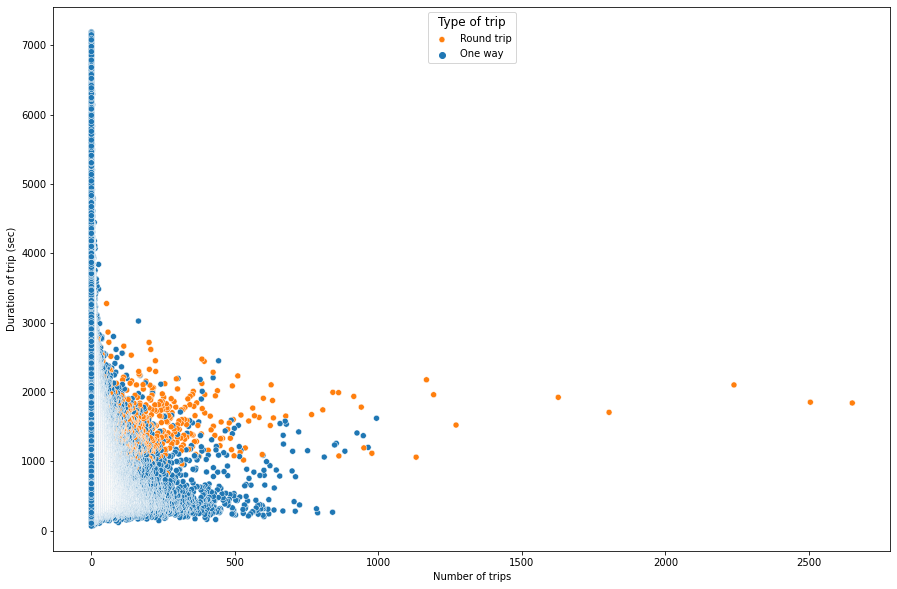

```python
plt.figure(figsize=(15,10))
g = sns.scatterplot(data=top_df,x="count", y="duration_sec", hue="round_trip");
g.set(xlabel="Number of trips", ylabel="Duration of trip (sec)");
plt.legend(title='Type of trip', loc='upper center', labels=['Round trip','One way'],title_fontsize="large");
```

> Some round trips are used way more often than the one way trip but tend to have a similar duration, while the one way trips are more spread out in term of duration, but only few routes are used very often.

As one of my friend noticed, it's a bit messy to read because of the trips that didn't happen often but took a long time, let's filter them out.

Let's see first if I can identify at what value I should exclude them. Let's see how they distribute between the routes taken 1 time and 100 times:

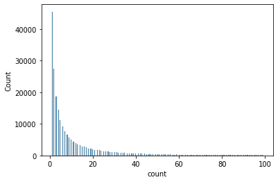

```python
sns.histplot(data=top_df[top_df['count'] < 100], x='count');
```

Let's zoom in in the first 20 and set a number of occurence of 10 000 counts that I want to exclude:

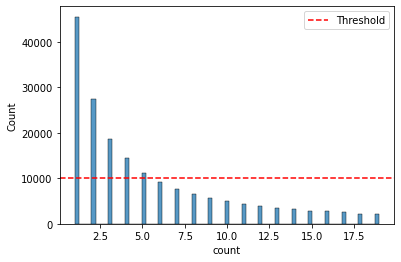

```python
sns.histplot(data=top_df[top_df['count'] < 20], x='count');
plt.axhline(y=10000, ls='--', c='red', label='Threshold');
plt.legend();
```

Let's see once we exclude these trips:

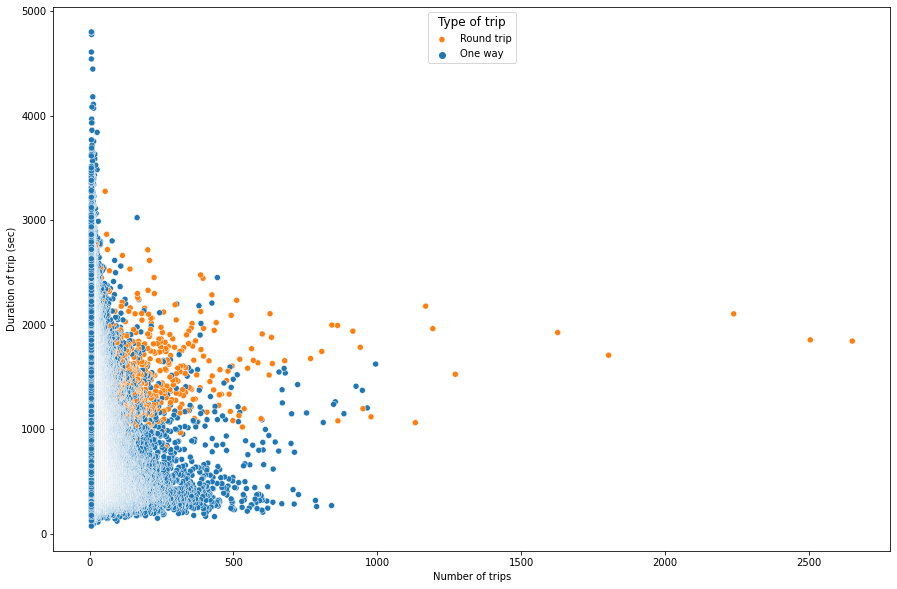

```python
plt.figure(figsize=(15,10))
g = sns.scatterplot(data=top_df[top_df['count']>5],x="count", y="duration_sec", hue="round_trip");
g.set(xlabel="Number of trips", ylabel="Duration of trip (sec)");
plt.legend(title='Type of trip', loc='upper center', labels=['Round trip','One way'],title_fontsize="large");
```

A bit clearer, but let's take a more radical approach and remove even more, all under 100 trips :

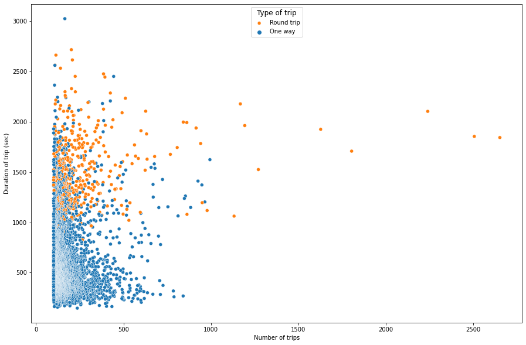

```python
plt.figure(figsize=(15,10))
g = sns.scatterplot(data=top_df[top_df['count']>100],x="count", y="duration_sec", hue="round_trip");
g.set(xlabel="Number of trips", ylabel="Duration of trip (sec)");
plt.legend(title='Type of trip', loc='upper center', labels=['Round trip','One way'],title_fontsize="large");
```

> Excluding the less used routes (less than 100 trips per year), we see that the one way routes tend to be shorter. One hypothesis could could be that these are trips taken by people going to work, while the round trips might be used by tourist taking time to enjoy the view.

## Rental time distribution

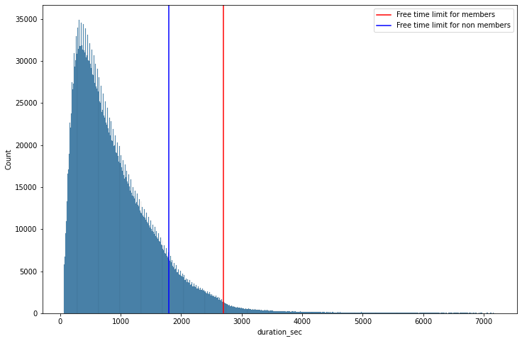

```python
plt.figure(figsize=(12,8))
sns.histplot(data=df, x='duration_sec');
plt.axvline(2700,color='r', label='Free time limit for members');
plt.axvline(1800,color='b', label='Free time limit for non members');
plt.legend();
```

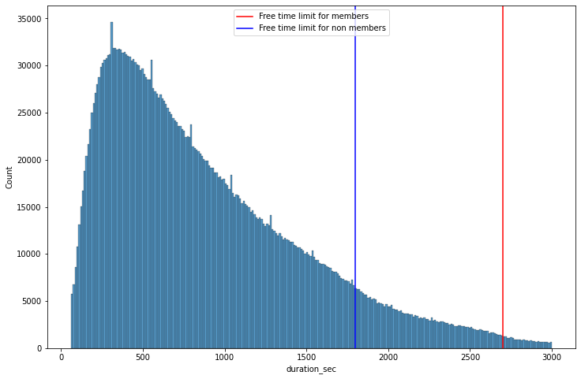

```python
plt.figure(figsize=(12,8))
sns.histplot(data=df[df['duration_sec'] < 3000], x='duration_sec');
plt.axvline(2700,color='r', label='Free time limit for members');
plt.axvline(1800,color='b', label='Free time limit for non members');
plt.legend(loc="upper center");
```

## How many trips per week (total, by members and non members)

```python
df['start_date']= pd.to_datetime(df['start_date'])
```

```python
resampled_df = df.set_index('start_date') #Moving the datatime column as an index to be able to resample
resampled_df['trip'] = 1 #Adding this to be able to track the total number of trips
resampled_df = resampled_df.resample('W',loffset=pd.DateOffset(days=1)).sum()
resampled_df['non_members'] = resampled_df['trip']- resampled_df['is_member'] # calculating the trips from non members
```

```python
resampled_df.head()
```

| start_date | start_station_code | end_station_code | duration_sec | is_member | trip | non_members |
| --- | --- | --- | --- | --- | --- | --- |
| 2020-04-20 | 102046085 | 102078320 | 16574080 | 13128 | 15944 | 2816 |
| 2020-04-27 | 208034846 | 208181799 | 35298530 | 25228 | 32475 | 7247 |
| 2020-05-04 | 346096879 | 346123666 | 61886388 | 38952 | 53894 | 14942 |
| 2020-05-11 | 288438270 | 288511677 | 44496131 | 36217 | 45049 | 8832 |
| 2020-05-18 | 478045244 | 477921004 | 84550616 | 53295 | 74550 | 21255 |

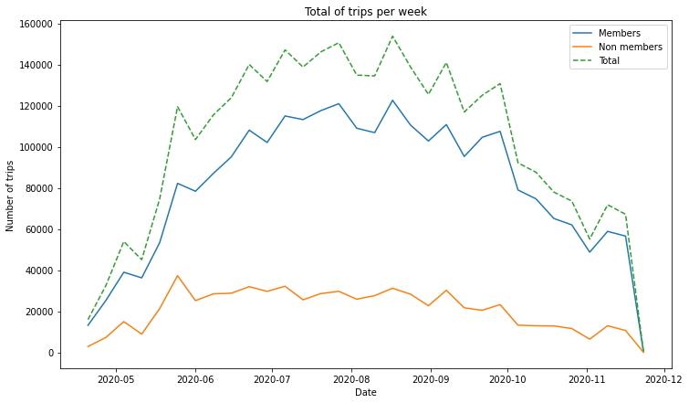

```python
plt.figure(figsize=(12,7))
g = sns.lineplot(data=resampled_df.loc[:,['is_member','non_members','trip']], dashes = False)
g.lines[2].set_linestyle("--")
plt.legend( labels=['Members','Non members','Total'],title_fontsize="large");
g.set(xlabel="Date", ylabel="Number of trips", title="Total of trips per week");
```

# Other request

## Request from Thib

Request from a friend asking the shortest time between our previous locations. We both moved since but used to live really close by and riding a bike was a clear example of lazin... time optimisation.

```python
query1 = df_stations.name.str.contains('Faillon')

code1 = df_stations[query1].code.values[0]
```

```python
query2 = df_stations.name.str.contains('Guizot / St-Denis')

code2 = df_stations[query2].code.values[0]
```

Generating the 2 possible routes

```python
route1 = str(code1) + "-" + str(code2)
route2 = str(code2) + "-" + str(code1)
print(route1,route2)
```

```
6327-6331 6331-6327
```

```python
shortest_time = df.loc[df['route'].isin([route1,route2])].sort_values(by='duration_sec').duration_sec.values[0]
```

```python
print(f"The shortest trip duration between the two stations was {shortest_time} seconds, whish is {round(shortest_time/60,2)} minutes")
```

```
The shortest trip duration between the two stations was 190 seconds, whish is 3.17 minutes
```

Another request from my friend to know how many times this route was used in 2020

```python
df.loc[df['route'].isin([route1,route2])].count()[0]
```

```
35
```

# Loading dataframes

As I close and reopen this Notebook, I frequently have to reload the dataframes in the Notebook, this section is dedicated to this.

## Main DF

```python
df = pd.read_pickle('pickles/df.pkl')
df.head()
```

|  | start_date | start_station_code | end_date | end_station_code | duration_sec | is_member | route |
| --- | --- | --- | --- | --- | --- | --- | --- |
| 0 | 2020-04-15 06:00:04 | 6212 | 2020-04-15 06:20:54 | 6250 | 1250 | 1 | 6212-6250 |
| 1 | 2020-04-15 06:05:41 | 6369 | 2020-04-15 06:32:47 | 6072 | 1626 | 1 | 6369-6072 |
| 2 | 2020-04-15 06:07:27 | 6207 | 2020-04-15 06:19:32 | 7038 | 724 | 1 | 6207-7038 |
| 3 | 2020-04-15 06:09:16 | 6202 | 2020-04-15 06:18:49 | 6212 | 572 | 1 | 6202-6212 |
| 4 | 2020-04-15 06:09:38 | 6159 | 2020-04-15 06:24:23 | 7067 | 885 | 1 | 6159-7067 |

## Top DF

```python
top_df= pd.read_pickle('pickles/top_df.pkl')
top_df.head()
```

| route | count | duration_sec | round_trip |
| --- | --- | --- | --- |
| 6501-6501 | 2651 | 1842.659374 | 1 |
| 6026-6026 | 2505 | 1854.134531 | 1 |
| 6036-6036 | 2239 | 2103.002680 | 1 |
| 7125-7125 | 1804 | 1707.531596 | 1 |
| 6023-6023 | 1627 | 1924.244622 | 1 |

## Top 10 trips

```python
top10_trips= pd.read_pickle('pickles/top_10.pkl')
top10_trips.head()
```

| route | count | duration_sec | from_lat | from_long | to_lat | to_long | mean_lat | mean_long | name_from | name_to |
| --- | --- | --- | --- | --- | --- | --- | --- | --- | --- | --- |
| 6036-6026 | 994 | 1622.658954 | 45.504242 | -73.553469 | 45.507610 | -73.551836 | 45.505926 | -73.552653 | de la Commune / St-Sulpice | de la Commune / Place Jacques-Cartier |
| 6501-6109 | 965 | 1202.513990 | 45.512801 | -73.531116 | 45.502659 | -73.527535 | 45.507730 | -73.529326 | Parc Jean-Drapeau (Chemin Macdonald) | Parc Plage |
| 6406-6036 | 948 | 1371.289030 | 45.480208 | -73.577599 | 45.504242 | -73.553469 | 45.492225 | -73.565534 | Marché Atwater | de la Commune / St-Sulpice |
| 6036-6406 | 926 | 1410.187905 | 45.504242 | -73.553469 | 45.480208 | -73.577599 | 45.492225 | -73.565534 | de la Commune / St-Sulpice | Marché Atwater |
| 6109-6501 | 884 | 1147.692308 | 45.502659 | -73.527535 | 45.512801 | -73.531116 | 45.507730 | -73.529326 | Parc Plage | Parc Jean-Drapeau (Chemin Macdonald) |